# 12. Local Search

Algorithm II

12. Local Search

WU Xiaokun 吴晓堃

xkun.wu [at] gmail

2021/12/10

## Coping with NP-completeness

**Q**. Suppose I need to solve an NP-hard problem. What should I do?  
**A**. Sacrifice one of three desired features.

- 1. Solve *arbitrary instances* of the problem.
- 2. Solve problem to *optimality*.
- 3. Solve problem in *polynomial time*.

# Gradient descent

## Gradient descent: vertex cover

**Vertex cover**. Given a graph $G = (V, E)$, find a subset of nodes $S$ of minimal cardinality such that for each $(u, v) \in E$, either $u$ or $v$ (or both) are in $S$.

**Neighbor relation**. $S \sim S'$ if $S'$ can be obtained from $S$ by adding or deleting a single node. Each vertex cover $S$ has at most $n$ neighbors.

**Gradient descent**. Start with $S = V$. If there is a neighbor $S'$ that is a vertex cover and has lower cardinality, replace $S$ with $S'$.

**Remark**. Algorithm terminates after at most $n$ steps since each update decreases the size of the cover by one.

## Gradient descent: vertex cover

**Local optimum**. No neighbor is strictly better.

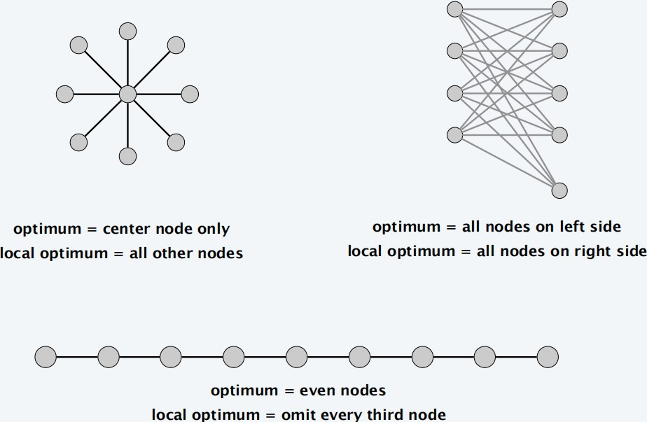

## Local search

**Local search**. Algorithm that explores the space of possible solutions in sequential fashion, moving from a current solution to a “nearby” one.

**Neighbor relation**. Let $S \sim S'$ be a neighbor relation for the problem.

**Gradient descent**. Let $S$ denote current solution. If there is a neighbor $S'$ of $S$ with strictly lower cost, replace $S$ with the neighbor whose cost is as small as possible. Otherwise, terminate the algorithm.

**Problem**. Stuck into local optimal solution.

# Metropolis algorithm

## Metropolis algorithm

**Metropolis algorithm**.

- Simulate behavior of a physical system according to principles of statistical mechanics.
- Globally biased toward “downhill” steps, but occasionally makes “uphill” steps to break out of local minima.

## Gibbs-Boltzmann function

**Gibbs-Boltzmann function**. The probability of finding a physical system in a state with energy $E$ is proportional to $e^{-E / (kT)}$, where $T > 0$ is temperature and $k$ is a constant.

- For any temperature $T > 0$, function is monotone decreasing function of energy $E$.
- System more likely to be in a lower energy state than higher one.
  - $T$ large: high and low energy states have roughly same probability
  - $T$ small: low energy states are much more probable

## Metropolis algorithm

**Metropolis algorithm**.

- Given a fixed temperature $T$, maintain current state $S$.
- Randomly perturb current state $S$ to new state $S' \in N(S)$.
  - If $E(S') ≤ E(S)$, update current state to $S'$.
  - Otherwise, update current state to $S'$ with probability $e^{- \Delta E / (kT)}$, where $\Delta E = E(S') - E(S) > 0$.

**Theorem**. Let $f_S(t)$ be fraction of first $t$ steps in which simulation is in state $S$. Then, assuming some technical conditions, with probability 1:

$$\lim_{t \to \infty} f_S(t) \frac{1}{Z} e^{-E(S)/(kT)},\ \text{where}\ Z = \sum_{S \in N(S)} e^{-E(S)/(kT)}$$

**Intuition**. Simulation spends roughly the right amount of time in each state, according to Gibbs-Boltzmann equation.

## Simulated annealing

**Simulated annealing**.

- $T$ large $\Rightarrow$ probability of accepting an uphill move is large.
- $T$ small $\Rightarrow$ uphill moves are almost never accepted.
- Idea: turn knob to control $T$.
- Cooling schedule: $T = T(i)$ at iteration $i$.

**Physical analog**.

- Take solid and raise it to high temperature, we do not expect it to maintain a nice crystal structure.
- Take a molten solid and freeze it very abruptly, we do not expect to get a perfect crystal either.
- **Annealing**: cool material gradually from high temperature, allowing it to reach equilibrium at succession of intermediate lower temperatures.

# Hopfield neural networks

## Hopfield neural networks

**Hopfield networks**. Simple model of an associative memory, in which a large collection of units are connected by an underlying network, and neighboring units try to correlate their states.

**Input**: Graph $G = (V, E)$ with integer (positive or negative) edge weights $w$.

**Configuration**. Node assignment $s_u = \pm 1$.

- Intuition: 1-bit of memory.

**Intuition**. If $w_{uv} < 0$, then $u$ and $v$ want to have the same state;  
if $w_{uv} > 0$ then $u$ and $v$ want different states.

**Note**. In general, no configuration respects all constraints.

## Hopfield neural networks

**Def**. With respect to a configuration $S$, edge $e = (u, v)$ is **good** if $w_e \times s_u \times s_v < 0$. That is, if $w_e < 0$ then $s_u = s_v$; if $w_e > 0$, then $s_u \ne s_v$.

**Def**. With respect to a configuration $S$, a node $u$ is **satisfied** if the weight of incident good edges $\ge$ weight of incident bad edges.

- ie. $\sum_{v: e=(u,v) \in E} w_e s_u s_v \le 0$

**Def**. A configuration is **stable** if all nodes are satisfied.

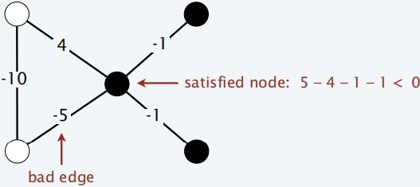

**Goal**. Find a stable configuration, if such a configuration exists.

## Hopfield neural networks

**Goal**. Find a stable configuration, if such a configuration exists.

**State-flipping algorithm**. Repeated flip state of an unsatisfied node.

`HOPFIELD-FLIP` ($G, w$)

1. $S =$ arbitrary configuration;
2. WHILE (current configuration is not stable):
   1. $u =$ unsatisfied node;
   2. $s_u = -s_u$;
3. RETURN $S$;

## State-flipping: example

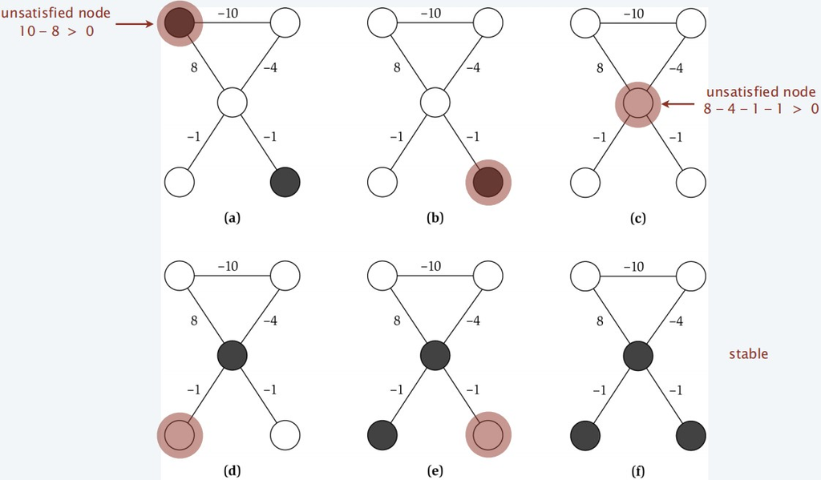

## State-flipping: correctness

**Theorem**. The state-flipping algorithm terminates with a stable configuration after at most $W = \sum_e | w_e |$ iterations.  
**Pf attempt**. Consider measure of progress $\Phi(S) = \#$ satisfied nodes.

## State-flipping: correctness

**Theorem**. The state-flipping algorithm terminates with a stable configuration after at most $W = \sum_e | w_e |$ iterations.  
**Pf**. Consider measure of progress $\Phi(S) = \sum_{e\ \text{good}} | w_e |$.

- Clearly $0 ≤ \Phi(S) ≤ W$.
- We show $\Phi(S)$ increases by at least 1 after each flip.

When $u$ flips state:

- all good edges incident to $u$ become bad
- all bad edges incident to $u$ become good
- all other edges remain the same

## Complexity of Hopfield neural network

**Hopfield network search problem**. Given a weighted graph, find a stable configuration if one exists.

**Hopfield network decision problem**. Given a weighted graph, does there exist a stable configuration?

**Remark**. The decision problem is trivially solvable (always yes), but there is no known poly-time algorithm for the search problem.

- polynomial in $n$ and $\log W$

# Maximum cut

## Maximum cut

**Maximum cut**. Given an undirected graph $G = (V, E)$ with positive integer edge weights $w_e$, find a cut $(A, B)$ such that the total weight of edges crossing the cut is maximized.

**Toy application**.

- $n$ activities, $m$ people.
- Each person wants to participate in two of the activities.
- Schedule each activity in the morning or afternoon to maximize number of people that can enjoy both activities.

**Real applications**. Circuit layout, statistical physics.

## Maximum cut

**Single-flip neighborhood**. Given a cut $(A, B)$, move one node from $A$ to $B$, or one from $B$ to $A$ if it improves the solution.

**Greedy algorithm**.

`MAX-CUT-LOCAL` ($G, w$)

1. $(A, B) =$ random cut;
2. WHILE (there exists an improving node $v$):
   1. IF $v \notin A$:
      1. $A = A \cup \{ v \}$;
      2. $B = B - \{ v \}$;
   2. ELSE $v \notin A$:
      1. $B = B \cup \{ v \}$;
      2. $A = A - \{ v \}$;
3. RETURN $(A, B)$;

## Maximum cut: local search analysis

**Theorem**. Let $(A, B)$ be a locally optimal cut and let $(A^\ast, B^\ast)$ be an optimal cut. Then $w(A, B) \ge \frac{1}{2} \sum_e w_e \ge \frac{1}{2} w(A^\ast, B^\ast)$.  
**Pf**.

- Local optimality implies that: $\forall u \in A: \sum_{v \in A} w_{uv} \le \sum_{v \in B} w_{uv}$
- Adding up all these inequalities yields: $2 \sum_{\{u,v\} \subseteq A} w_{uv} \le \sum_{u \in A, v \in B} w_{uv} = w(A, B)$
- Similarly: $2 \sum_{\{u,v\} \subseteq B} w_{uv} \le \sum_{u \in A, v \in B} w_{uv} = w(A, B)$
- Now, $\sum_{e \in E} w_e = \underbrace{\sum_{\{u,v\} \subseteq A} w_{uv}}_{\le \frac{1}{2} w(A,B)} + \underbrace{\sum_{u \in A, v \in B} w_{uv}}_{w(A,B)} + \underbrace{\sum_{\{u,v\} \subseteq B} w_{uv}}_{\le \frac{1}{2} w(A,B)} \le 2 w(A,B)$

## Maximum cut: big improvement flips

**Local search**. Within a factor of $2$ for MAX-CUT, but not poly-time!

**Big-improvement-flip algorithm**. Only choose a node which, when flipped, increases the cut value by at least $\frac{2 \epsilon}{n} w(A,B)$.

**Claim**. Upon termination, big-improvement-flip algorithm returns a cut $(A, B)$ such that $(2 + \epsilon) w(A, B) \ge w(A^\ast, B^\ast)$.  
**Pf idea**. Add $\frac{2 \epsilon}{n} w(A,B)$ to each inequality in original proof.

**Claim**. Big-improvement-flip algorithm terminates after $O(\epsilon^{-1} n \log W)$ flips, where $W = \sum_e w_e$.

- Each flip improves cut value by at least a factor of $(1 + \epsilon / n)$.
- After $n / \epsilon$ iterations the cut value improves by a factor of $2$.
- Cut value can be doubled at most $\log_2 W$ times.

## Maximum cut: context

**Theorem**. [Sahni-Gonzales 1976] There exists a $\frac{1}{2}$-approximation algorithm for MAX-CUT.

**Theorem**. There exists an $0.878$-approximation algorithm for MAX-CUT.

**Theorem**. Unless $\mathcal{P} = \mathcal{NP}$, no $0.942$-approximation algorithm for MAX-CUT.

## Neighbor relations for max cut

**$1$-flip neighborhood**. Cuts $(A, B)$ and $(Aʹ, Bʹ)$ differ in exactly one node.

**$k$-flip neighborhood**. Cuts $(A, B)$ and $(Aʹ, Bʹ)$ differ in at most $k$ nodes.

**KL-neighborhood**. [Kernighan-Lin 1970]

- To form neighborhood of $(A, B)$:
  - Iteration $1$: flip node from $(A, B)$ that results in best cut value $(A_1, B_1)$, and mark that node.
  - Iteration $i$: flip node from $(A_{i–1}, B_{i–1})$ that results in best cut value $(A_i, B_i)$ among all nodes not yet marked.
- Neighborhood of $(A, B) = (A_1, B_1), .., (A_{i–1}, B_{i–1})$.
- Neighborhood includes some very long sequences of flips, but without the computational overhead of a $k$-flip neighborhood.
- Practice: powerful and useful framework.
- Theory: explain and understand its success in practice.

# Nash equilibria

## Multicast routing

**Multicast routing**. Given a directed graph $G = (V, E)$ with edge costs $c_e \ge 0$, a source node $s$, and $k$ agents located at terminal nodes $t_1, .., t_k$. Agent $j$ must construct a path $P_j$ from node $s$ to its terminal $t_j$.

**Fair share**. If $x$ agents use edge $e$, they each pay $c_e / x$.

| 1 | 2 | cost 1 | cost 2 |
| --- | --- | --- | --- |
| outer | outer | 4 | 8 |
| outer | middle | 4 | 5 + 1 |
| middle | outer | 5 + 1 | 8 |
| middle | middle | 5/2 + 1 | 5/2 + 1 |

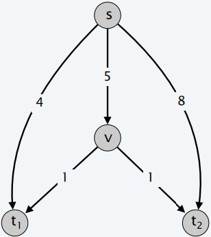

## Multicast routing

**Best response dynamics**. Each agent is continually prepared to improve its solution in response to changes made by other agents.

**Nash equilibrium**. Solution where no agent has an incentive to switch.

**Fundamental question**. When do Nash equilibria exist?

**Ex**:

1. Two agents start with outer paths.
2. Agent 1 has no incentive to switch paths (since $4 < 5 + 1)$, but agent 2 does (since $8 > 5 + 1$).
3. Once this happens, agent 1 prefers middle path (since $4 > 5/2 + 1$).
4. Both agents using middle path is a Nash equilibrium.

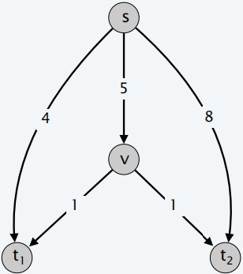

## Nash equilibrium and local search

**Local search algorithm**. Each agent is continually prepared to improve its solution in response to changes made by other agents.

**Analogies**.

- Nash equilibrium : local search.
- Best response dynamics : local search algorithm.
- Unilateral move by single agent : local neighborhood.

**Contrast**. Best-response dynamics need not terminate since no single objective function is being optimized.

## Socially optimum

**Social optimum**. Minimizes total cost to all agent.

**Observation**. In general, there can be many Nash equilibria.  
Even when its unique, it does not necessarily equal the social optimum.

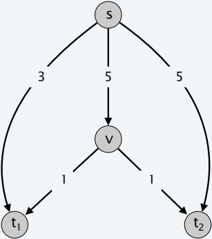

social optimum = $7$  
unique Nash equilibrium = $8$

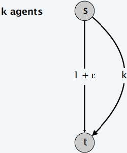

## Price of stability

**Price of stability**. Ratio of best Nash equilibrium to social optimum.

**Fundamental question**. What is price of stability?

**Ex**: Price of stability = $\Theta(\log k)$.  
Social optimum. Everyone takes bottom paths.  
Unique Nash equilibrium. Everyone takes top paths.  
Price of stability. $H(k) / (1 + \epsilon)$.

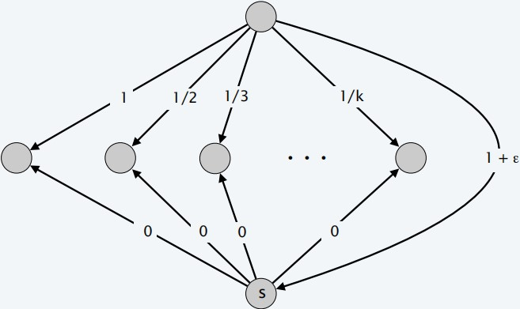

## Finding a Nash equilibrium

**Theorem**. The following algorithm terminates with a Nash equilibrium.

`BEST-RESPONSE-DYNAMICS` ($G, c, k$)

1. FOR $j = 1 .. k$:
   1. $P_j =$ any path for agent $j$;
2. WHILE (not a Nash equilibrium):
   1. $j$ = some agent who can improve by switching paths;
   2. $P_j$ = better path for agent $i$;
3. RETURN $(P_1, .., P_k)$;

**Pf**. Consider a set of paths $P_1, .., P_k$.

- Let $x_e$ denote the number of paths that use edge $e$.
- Let $\Phi(P_1, .., P_k) = \sum_{e \in E} c_e H(x_e)$ be a potential function, where $H(0) = 0, H(k) = \sum_{i=i..k} \frac{1}{i}$
- Since there are only finitely many sets of paths, it suffices to show that $\Phi$ strictly decreases in each step.

## Finding a Nash equilibrium

**Pf**. [ continued ]

- Consider agent $j$ switching from path $P_j$ to path $P_j'$.
- Agent $j$ switches because $\underbrace{\sum_{f \in P_j' - P_j} \frac{c_f}{x_f + 1}}_{\text{newly incurred cost}} < \underbrace{\sum_{e \in P_j - P_j'} \frac{c_e}{x_e}}_{\text{cost saved}}$.
- $\Phi$ increases by $\sum_{f \in P_j' - P_j} c_f [H(x_f + 1) - H(x_f)] = \sum_{f \in P_j' - P_j} \frac{c_f}{x_f + 1}$.
- $\Phi$ decreases by $\sum_{e \in P_j - P_j'} c_e [H(x_e) - H(x_e - 1)] = \sum_{e \in P_j - P_j'} \frac{c_e}{x_e}$.
- Thus, net change in $\Phi$ is negative.

## Bounding the price of stability

**Lemma**. Let $C(P_1, .., P_k)$ denote the total cost of selecting paths $P_1, .., P_k$.  
For any set of paths $P_1, .., P_k$, we have

$$C(P_1, .., P_k) \le \Phi(P_1, .., P_k) \le H(k) \cdot C(P_1, .., P_k)$$

**Pf**. Let $x_e$ denote the number of paths containing edge $e$.

- Let $E^+$ denote set of edges that belong to at least one of the paths.  
  Then,

$$C(P_1, .., P_k) = \sum_{e \in E^+} c_e \le \underbrace{\sum_{e \in E^+} c_e H(x_e)}_{\Phi(P_1, .., P_k)} \le \sum_{e \in E^+} c_e H(k) = H(k) \cdot C(P_1, .., P_k)$$

## Bounding the price of stability

**Theorem**. There is a Nash equilibrium for which the total cost to all agents exceeds that of the social optimum by at most a factor of $H(k)$.  
**Pf**.

- Let $(P_1^\ast, .., P_k^\ast)$ denote a set of socially optimal paths.
- Run best-response dynamics algorithm starting from $P^\ast$.
- Since $\Phi$ is monotone decreasing $\Phi(P_1, .., P_k) \le \Phi(P_1^\ast, .., P_k^\ast)$.

$$C(P_1, .., P_k) \le \Phi(P_1, .., P_k) \le \Phi(P_1^\ast, .., P_k^\ast) \le H(k) \cdot C(P_1^\ast, .., P_k^\ast)$$

## Summary

**Existence**. Nash equilibria always exist for $k$-agent multicast routing with fair sharing.

**Price of stability**. Best Nash equilibrium is never more than a factor of $H(k)$ worse than the social optimum.

**Fundamental open problem**. Find any Nash equilibria in poly-time.